# 5일차

```python
import pandas as pd
import numpy as np
import seaborn as sns
import matplotlib.pyplot as plt
%matplotlib inline
```

```python
df = pd.read_csv('test2.csv')
df.shape
```

```
(20631, 26)
```

```python
df.head().T
```

|  | 0 | 1 | 2 | 3 | 4 |
| --- | --- | --- | --- | --- | --- |
| unit | 1.0000 | 1.0000 | 1.0000 | 1.0000 | 1.0000 |
| cycle | 1.0000 | 2.0000 | 3.0000 | 4.0000 | 5.0000 |
| op_1 | -0.0007 | 0.0019 | -0.0043 | 0.0007 | -0.0019 |
| op_2 | -0.0004 | -0.0003 | 0.0003 | 0.0000 | -0.0002 |
| op_3 | 100.0000 | 100.0000 | 100.0000 | 100.0000 | 100.0000 |
| T2 | 518.6700 | 518.6700 | 518.6700 | 518.6700 | 518.6700 |
| T24 | 641.8200 | 642.1500 | 642.3500 | 642.3500 | 642.3700 |
| T30 | 1589.7000 | 1591.8200 | 1587.9900 | 1582.7900 | 1582.8500 |
| T50 | 1400.6000 | 1403.1400 | 1404.2000 | 1401.8700 | 1406.2200 |
| P2 | 14.6200 | 14.6200 | 14.6200 | 14.6200 | 14.6200 |
| P15 | 21.6100 | 21.6100 | 21.6100 | 21.6100 | 21.6100 |
| P30 | 554.3600 | 553.7500 | 554.2600 | 554.4500 | 554.0000 |
| Nf | 2388.0600 | 2388.0400 | 2388.0800 | 2388.1100 | 2388.0600 |
| Nc | 9046.1900 | 9044.0700 | 9052.9400 | 9049.4800 | 9055.1500 |
| epr | 1.3000 | 1.3000 | 1.3000 | 1.3000 | 1.3000 |
| Ps30 | 47.4700 | 47.4900 | 47.2700 | 47.1300 | 47.2800 |
| phi | 521.6600 | 522.2800 | 522.4200 | 522.8600 | 522.1900 |
| NRf | 2388.0200 | 2388.0700 | 2388.0300 | 2388.0800 | 2388.0400 |
| NRc | 8138.6200 | 8131.4900 | 8133.2300 | 8133.8300 | 8133.8000 |
| BPR | 8.4195 | 8.4318 | 8.4178 | 8.3682 | 8.4294 |
| farB | 0.0300 | 0.0300 | 0.0300 | 0.0300 | 0.0300 |
| htBleed | 392.0000 | 392.0000 | 390.0000 | 392.0000 | 393.0000 |
| Nf_dmd | 2388.0000 | 2388.0000 | 2388.0000 | 2388.0000 | 2388.0000 |
| PCNfR_dmd | 100.0000 | 100.0000 | 100.0000 | 100.0000 | 100.0000 |
| W31 | 39.0600 | 39.0000 | 38.9500 | 38.8800 | 38.9000 |
| W32 | 23.4190 | 23.4236 | 23.3442 | 23.3739 | 23.4044 |

#### column의 이해

- column의 의미를 모르더라도 어떤 절차를 거쳐서 진행할 수 있는가에 대한 방법을 학습

```python
import pandas_profiling as pp

report = pp.ProfileReport(df)
report.to_file('test2_report.html')
```

## Data Exploration

- 분석 방향성: 설비 예방보전
- Label을 분석방향성에 맞게 만들어내야 함
- cycle은 몇 번 사용한지에 대한 정보이므로 cycle로 그래프 그리는 것부터 시작

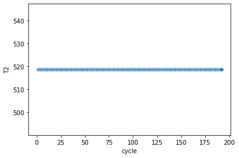

```python
one_unit = df.loc[df['unit'] == 1]
sns.scatterplot(data = one_unit, x='cycle', y='T2')
```

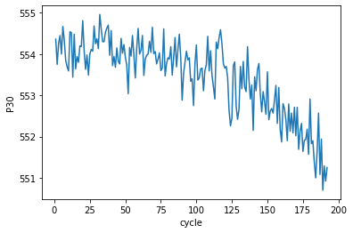

```python
sns.lineplot(data=one_unit, x='cycle', y='P30')

# cycle이 증가할수록 P30 값이 줄어드는 경향이 있음
```

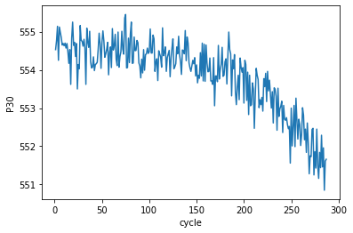

```python
one_unit = df.loc[df['unit'] == 2]
sns.lineplot(data=one_unit, x='cycle', y='P30')
```

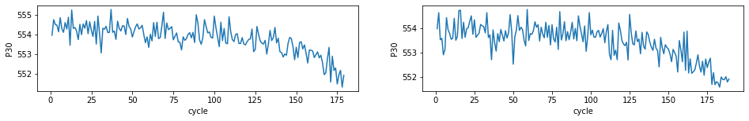

```python
fig, (ax1, ax2) = plt.subplots(ncols=2)
fig.set_size_inches(16, 2)
left = df.loc[df['unit'] == 3]
right = df.loc[df['unit'] == 4]
sns.lineplot(data=left, x='cycle', y='P30', ax=ax1)
sns.lineplot(data=right, x='cycle', y='P30', ax=ax2)

# 그렇다면 cycle을 Label로 두면 되지 않을까?
```

```python
# 'cycle' 컬럼을 그대로 label로 사용하면 안되는 이유는?
# cycle은 고장까지 얼마나 남았다는 정보가 아니라
# 몇 번을 사용했다는 정보임
# unit마다 잔존수명이 다르기 때문

df.groupby('unit').agg({'cycle': np.max})

# '센서들이 어떤 값이 되었을 때 몇 회쯤 사용한 엔진이다'는
# 방식으로 학습하게 될 것
# 분석방향성에 맞게 label을 새로 설정해야 함
```

| unit | cycle |
| --- | --- |
| 1 | 192 |
| 2 | 287 |
| 3 | 179 |
| 4 | 189 |
| 5 | 269 |
| ... | ... |
| 96 | 336 |
| 97 | 202 |
| 98 | 156 |
| 99 | 185 |
| 100 | 200 |

100 rows × 1 columns

### RUL(Remaining Useful Life)

- 잔존 유효 수명 컬럼을 새로 만들어 주자
- 각 unit마다 최대 cycle이 서로 다름을 반영
- 서로 다른 엔진에서 cycle이 다를 때, 잔존수명이 같지 않음
- 'RUL' 컬럼을 만들어서 RUL의 값이 같을 때 잔존수명이 같게 만들어 줌

```python
unit_no = 3
one_unit = df.loc[df['unit'] == unit_no]
one_unit.tail()
```

|  | unit | cycle | op_1 | op_2 | op_3 | T2 | T24 | T30 | T50 | P2 | ... | phi | NRf | NRc | BPR | farB | htBleed | Nf_dmd | PCNfR_dmd | W31 | W32 |
| --- | --- | --- | --- | --- | --- | --- | --- | --- | --- | --- | --- | --- | --- | --- | --- | --- | --- | --- | --- | --- | --- |
| 653 | 3 | 175 | -0.0030 | 0.0004 | 100.0 | 518.67 | 643.15 | 1603.74 | 1424.17 | 14.62 | ... | 520.34 | 2388.14 | 8238.86 | 8.5066 | 0.03 | 396 | 2388 | 100.0 | 38.49 | 22.9909 |
| 654 | 3 | 176 | -0.0008 | 0.0002 | 100.0 | 518.67 | 643.93 | 1595.61 | 1438.51 | 14.62 | ... | 520.91 | 2388.12 | 8251.82 | 8.5245 | 0.03 | 396 | 2388 | 100.0 | 38.49 | 23.0656 |
| 655 | 3 | 177 | -0.0041 | -0.0002 | 100.0 | 518.67 | 643.68 | 1601.21 | 1423.50 | 14.62 | ... | 520.19 | 2388.16 | 8249.86 | 8.5286 | 0.03 | 397 | 2388 | 100.0 | 38.37 | 23.0336 |
| 656 | 3 | 178 | -0.0010 | 0.0001 | 100.0 | 518.67 | 643.66 | 1606.50 | 1430.55 | 14.62 | ... | 520.14 | 2388.12 | 8253.84 | 8.5351 | 0.03 | 399 | 2388 | 100.0 | 38.57 | 23.1323 |
| 657 | 3 | 179 | 0.0012 | 0.0000 | 100.0 | 518.67 | 643.51 | 1604.80 | 1428.23 | 14.62 | ... | 519.53 | 2388.20 | 8255.34 | 8.5056 | 0.03 | 398 | 2388 | 100.0 | 38.40 | 22.9562 |

5 rows × 26 columns